# PD 5

Witold Merkel

30 - 04 - 2019

# 1 Wprowadzenie

Celem tego raportu jest przybliżenie drzew z pakietu `rpart`, wykorzystamy do tego klasyfikacje na zbiorze `titanic`. Będziemy przewidywać czy dany pasażer przeżył katastrofę czy też nie.

Najpierw szybko opiszę te hiperparametry, które będziemy zmieniać (te o których jest mowa w artykule):

- `minsplit` - minimalna liczba obserwacji, która musi występować w węźle, aby próbować go dalej dzielić,
- `minbucket` - minimalna licza obserwacji w liściu drzewa,
- `cp` - jeżeli podział nie poprawi jakości modelu o te wartość, to nie jest robiony,
- `maxdepth` - maksymalna głębokość drzewa.

W całym raporcie będziemy posługiwać się dwiema miarami równolegle: `acc` oraz `auc`.

Przed przejściam do pracy sprawdźmy jak wygląda ramka danych.

```r
head(titanic)
```

|  | gender | age | class | embarked | fare | sibsp | parch | survived |
| --- | --- | --- | --- | --- | --- | --- | --- | --- |
| 1 | male | 42 | 3rd | Southampton | 7.11 | 0 | 0 | no |
| 2 | male | 13 | 3rd | Southampton | 20.05 | 0 | 2 | no |
| 3 | male | 16 | 3rd | Southampton | 20.05 | 1 | 1 | no |
| 4 | female | 39 | 3rd | Southampton | 20.05 | 1 | 1 | yes |
| 5 | female | 16 | 3rd | Southampton | 7.13 | 0 | 0 | yes |
| 6 | male | 25 | 3rd | Southampton | 7.13 | 0 | 0 | yes |

# 2 Zestaw hiperparametrów z artykułu

W artykule napisane jest, że optymalny zestaw hiperparametrów to:

- `minsplit` = 13,
- `minbucket` = 5,
- `cp` = 0.002,
- `maxdepth` = 19.

Model stworzony z takimi hiperparametrami osiąga następujace dokładności:

```r
perf_classif_art
```

```
##       auc       acc
## 0.7753661 0.7874794
```

# 3 Zestaw hiperparametrów proponowany przez pakiet

Defaultowe hiperparametry dla tego modelu są ustawione następujaco:

- `minsplit` = 20,
- `minbucket` = 7,
- `cp` = 0.01,
- `maxdepth` = 30.

Model stworzony z takimi hiperparametrami osiąga następujace dokładności:

```r
perf_classif_raw
```

```
##       auc       acc
## 0.7733464 0.7841845
```

# 4 Zestaw hiperparametrów otrzymany przez random search

Do randomowego szukania hiperparametrów zastosowałem metodę znaną już z poprzedniej pracy domowej z 2000 prób. Zgodnie z podpowiedziami przedziały szukania optymalnych parametrów ustawiłem w taki sposób, żeby zawierały wartości domyślne. Wykonałem to pare razy, aby udoskonalić przedziały. Na przykład gdy jakaś wartość była przy krańcu przedziału to powiększałem go z tej strony.

Hiperparametry otrzymane w ten sposób prezentują się następująco:

- `minsplit` = 7,
- `minbucket` = 47,
- `cp` = 0.006376359,
- `maxdepth` = 15.

Model stworzony z takimi hiperparametrami osiąga następujace dokładności:

```r
perf_classif_hyper
```

```
##       auc       acc
## 0.7478240 0.7512356
```

# 5 Omówienie najlepszego modelu

Widzimy, z wartości `acc` i `auc`, że najlepszy jest model zbudowany na hiperparametrach proponowanych przez artykuł. Z pośród wszystkich 3, przoduje on jeżeli chodzi o jedną i drugą miarę zatem jest niekwestionowanym liderem.

Zobaczmy jak wygląda podejmowanie decyzji w tym drzewie. Wykorzystamy do tego taką metodę, żeby reguły decyzyjne były widoczne nad każdym węzłem, który nie jest lisciem. Dzięki temu będziemy mogli łatwo sprawdzić, do którego liścia klasyfikuje się konkretny przypadek. Moim zdaniem jest to o wiele bardziej czytelne niż zwykłe wypisywanie decyzji po kolei.

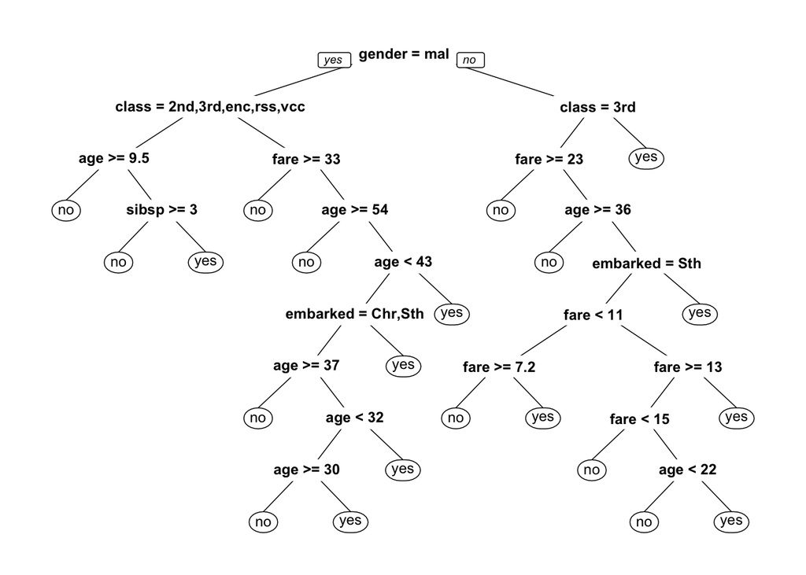

Sprawdźmy jednak jak wyglądają wypisane reguły decyzyjne.

```r
print(tree_art)
```

```
## n= 1600
##
## node), split, n, loss, yval, (yprob)
##       * denotes terminal node
##
##   1) root 1600 502 no (0.68625000 0.31375000)
##     2) gender=male 1248 248 no (0.80128205 0.19871795)
##       4) class=2nd,3rd,engineering crew,restaurant staff,victualling crew 1077 170 no (0.84215413 0.15784587)
##         8) age>=9.5 1048 153 no (0.85400763 0.14599237) *
##         9) age< 9.5 29  12 yes (0.41379310 0.58620690)
##          18) sibsp>=3 11   0 no (1.00000000 0.00000000) *
##          19) sibsp< 3 18   1 yes (0.05555556 0.94444444) *
##       5) class=1st,deck crew 171  78 no (0.54385965 0.45614035)
##        10) fare>=32.5 75  23 no (0.69333333 0.30666667) *
##        11) fare< 32.5 96  41 yes (0.42708333 0.57291667)
##          22) age>=54 8   0 no (1.00000000 0.00000000) *
##          23) age< 54 88  33 yes (0.37500000 0.62500000)
##            46) age< 42.5 69  29 yes (0.42028986 0.57971014)
##              92) embarked=Cherbourg,Southampton 56  27 yes (0.48214286 0.51785714)
##               184) age>=36.5 21   8 no (0.61904762 0.38095238) *
##               185) age< 36.5 35  14 yes (0.40000000 0.60000000)
##                 370) age< 31.5 21  10 no (0.52380952 0.47619048)
##                   740) age>=29.5 6   1 no (0.83333333 0.16666667) *
##                   741) age< 29.5 15   6 yes (0.40000000 0.60000000) *
##                 371) age>=31.5 14   3 yes (0.21428571 0.78571429) *
##              93) embarked=Belfast 13   2 yes (0.15384615 0.84615385) *
##            47) age>=42.5 19   4 yes (0.21052632 0.78947368) *
##     3) gender=female 352  98 yes (0.27840909 0.72159091)
##       6) class=3rd 155  72 no (0.53548387 0.46451613)
##        12) fare>=23.07 26   2 no (0.92307692 0.07692308) *
##        13) fare< 23.07 129  59 yes (0.45736434 0.54263566)
##          26) age>=35.5 13   2 no (0.84615385 0.15384615) *
##          27) age< 35.5 116  48 yes (0.41379310 0.58620690)
##            54) embarked=Southampton 62  30 no (0.51612903 0.48387097)
##             108) fare< 10.55555 33  13 no (0.60606061 0.39393939)
##               216) fare>=7.1503 28   9 no (0.67857143 0.32142857) *
##               217) fare< 7.1503 5   1 yes (0.20000000 0.80000000) *
##             109) fare>=10.55555 29  12 yes (0.41379310 0.58620690)
##               218) fare>=12.6206 21  10 no (0.52380952 0.47619048)
##                 436) fare< 15.14 5   1 no (0.80000000 0.20000000) *
##                 437) fare>=15.14 16   7 yes (0.43750000 0.56250000)
##                   874) age< 21.5 8   3 no (0.62500000 0.37500000) *
##                   875) age>=21.5 8   2 yes (0.25000000 0.75000000) *
##               219) fare< 12.6206 8   1 yes (0.12500000 0.87500000) *
##            55) embarked=Cherbourg,Queenstown 54  16 yes (0.29629630 0.70370370) *
##       7) class=1st,2nd,restaurant staff,victualling crew 197  15 yes (0.07614213 0.92385787) *
```

Patrząc na to jak ustawione są parametry proponowane przez artykuł, można sie domyślać, że będzie to rozbudowane drzewo.